# Palmer Penguins Size Analysis: A Comprehensive Study

## Visualization

Visualizations help interpret the data effectively.

### Scatter Plot: Bill Length vs. Flipper Length

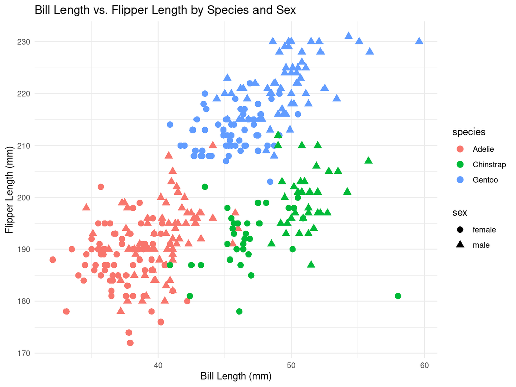

```r
ggplot(penguins_clean, aes(x = bill_length_mm, y = flipper_length_mm, color = species, shape = sex)) +
  geom_point(size = 3) +
  labs(
    title = "Bill Length vs. Flipper Length by Species and Sex",
    x = "Bill Length (mm)",
    y = "Flipper Length (mm)"
  ) +
  theme_minimal()
```

**Insight:** Gentoo penguins cluster in the upper-right, indicating larger sizes, with males slightly separated from females.

### Box Plot: Body Mass Distribution

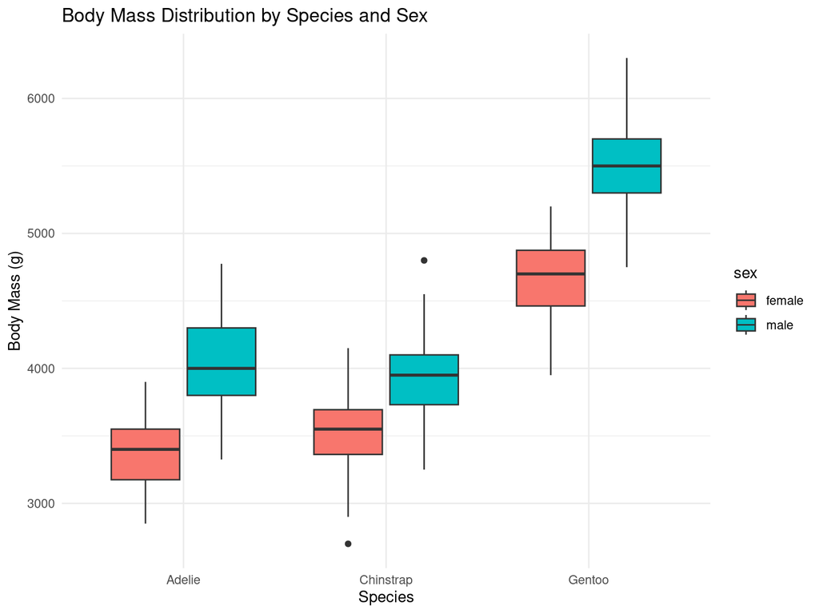

```r
ggplot(penguins_clean, aes(x = species, y = body_mass_g, fill = sex)) +
  geom_boxplot() +
  labs(
    title = "Body Mass Distribution by Species and Sex",
    x = "Species",
    y = "Body Mass (g)"
  ) +
  theme_minimal()
```

**Insight:** Gentoo males have the highest median body mass, with noticeable variation across species.

### Facet Plot: Species-Specific Differences

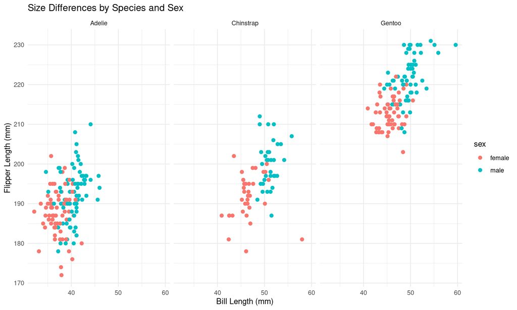

```r
ggplot(penguins_clean, aes(x = bill_length_mm, y = flipper_length_mm, color = sex)) +
  geom_point(size = 2) +
  facet_wrap(~ species) +
  labs(
    title = "Size Differences by Species and Sex",
    x = "Bill Length (mm)",
    y = "Flipper Length (mm)"
  ) +
  theme_minimal()
```

**Insight:** Facets highlight distinct measurement ranges for each species, with sex differences most pronounced in Gentoo.

## Conclusion

This project demonstrates proficiency in R programming, data cleaning with `dplyr`, statistical analysis with t-tests, and visualization with `ggplot2`, aligning with the Google Data Analytics Certificate’s curriculum. Future work could explore correlations between measurements or environmental factors like island location.

## References

- Palmer Penguins dataset: Horst AM, Hill AP, Gorman KB (2020). *palmerpenguins: Palmer Archipelago (Antarctica) penguin data*. R package version 0.1.0.
- Google Data Analytics Certificate, Coursera.